# NMR-based metabolomic analysis of the dataset MTBLS242: serum samples

Institute for Bioengineering of Catalonia

October 4, 2019

This is an example of using AlpsNMR package on the MTBLS242 dataset structured as a pipeline so that inputs are needed and outputs are obtained in the selected folders. Edit “inputs” to match your parameters and just run the “code to run” for the pipeline execution. However, you can see the vignettes and use the functions as you wish. You can download the MTBLS242 dataset from MetaboLights database: https://www.ebi.ac.uk/metabolights/MTBLS242

```r
library(AlpsNMR)
```

# Pipeline preparation

To work as in a pipeline manner we need to set an output directory. We can set the number of cores of your computer for parallelization.

```r
# Set a folder to keep results
output_dir <- "C:/Users/fmadrid/MTBLS242/results"

# How many cores to use for parallelization
num_workers <- 12
```

# Node 1: Load samples

Loads samples from a specified directory into a `nmr_dataset` object. Then we can save the loaded data into the output directory.

## Input parameters

```r
# Path of NMR samples downloaded from https://www.ebi.ac.uk/metabolights/MTBLS242:
dataset_path_nmr <- "C:/Users/fmadrid/MTBLS242/MTBLS242"

# Files/directories ending in "s" corresponding to the spectra in the dataset:
filename_glob <- "*s"
```

## Code to run

```r
NMRExperiments <- as.character(fs::dir_ls(dataset_path_nmr, glob = filename_glob))
plan(multiprocess, workers = num_workers)
nmr_dataset <- nmr_read_samples(NMRExperiments)
plan(sequential)
```

# Node 2: Append metadata

We now merge the metadata. To do that, you need an Excel file containing a first column called “NMRExperiments” with the name of the imported spectra (it does not have to be the name of the individuals).

## Input parameters

```r
# Path where metada is contained
excel_file <- "C:/Users/fmadrid/MTBLS242/nmr_dataset_metadata_tidy.xlsx"
```

## Code to run

```r
nmr_dataset <- nmr_meta_add_tidy_excel(nmr_dataset, excel_file)
```

# Node 3: Interpolation

Interpolation is used to unify the ppm axis from all spectra. However, you also can set a range for next steps avoiding noise regions from here. Note that ppm resolution is automatically calculated with the function `nmr_ppm_resolution` in “Code to run”.

## Input parameters

```r
ppm_range_start <- 0.7
ppm_range_end <- 9.5
```

## Code to run

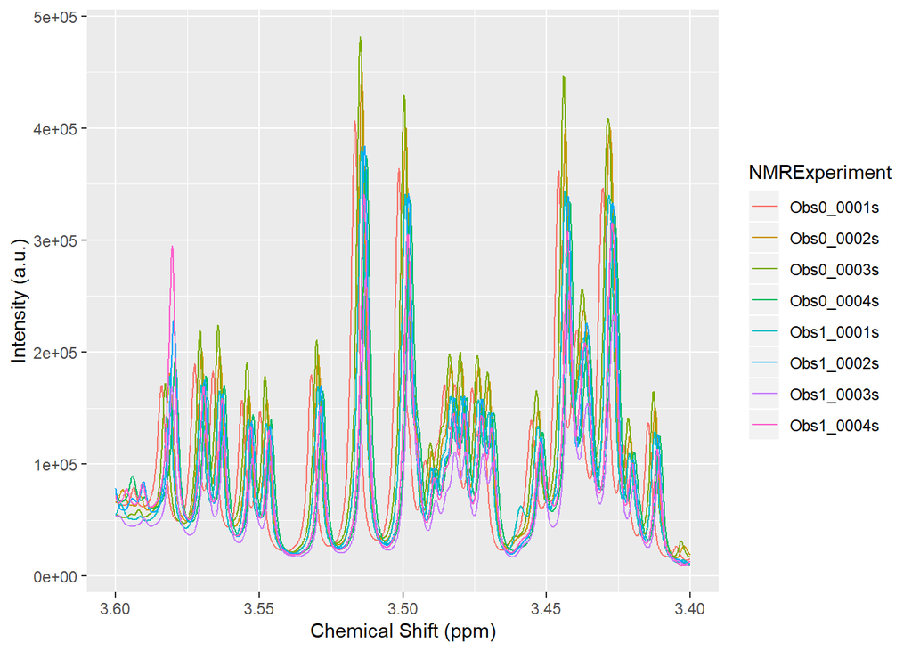

```r
ppm_resolution <- unlist(nmr_ppm_resolution(nmr_dataset[1]))
axis <- c(min = ppm_range_start, max = ppm_range_end, by = ppm_resolution)
nmr_dataset <- nmr_interpolate_1D(nmr_dataset, axis = axis)

plot(nmr_dataset,
  NMRExperiment = c(
  "Obs0_0001s",
  "Obs0_0002s",
  "Obs0_0003s",
  "Obs0_0004s",
  "Obs1_0001s",
  "Obs1_0002s",
  "Obs1_0003s",
  "Obs1_0004s"),
  chemshift_range = c(3.40, 3.60))
```

# Node 4: Region Exclusion

Here it is important to know what type of signals can mask the results due to their intensity or what type of solvent has been used in sample processing since this can create artifacts in the spectra and should be removed. In this case, the biological samples correspond to serum, which contains a lot of water and its signal should be removed from further steps. To do this, we define a vector containing the range (min ppm value, max ppm value) of the water signal, but other signals can be eliminated, for example: exclude_regions <- list(water = c(4.5, 5.1), methanol = c(3.33, 3.34))

## Input parameters

```r
exclude_regions <-  list(water = c(4.5, 5.1))
```

## Code to run

```r
nmr_dataset <- nmr_exclude_region(nmr_dataset, exclude = exclude_regions)
```

# Node 5: Initial Outlier Rejection

The robust principal component analysis (rPCA) for outlier detection gives an idea of potential outliers. A proposed threshold, based on quantiles, for Q residual and T2 score values, results less sensitive to extreme intensities. Then you choose if any sample should be excluded. The plot below indicated that a sample “Obs0_0283s” is extremely different than the other samples. The function is prepared to annotated samples that are in the top-right corner, exhibiting high differences.

## Input parameters

```r
# Nothing
```

## Code to run

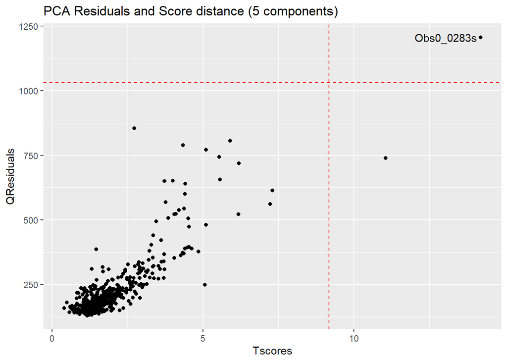

```r
pca_outliers <- nmr_pca_outliers_robust(nmr_dataset)
nmr_pca_outliers_plot(nmr_dataset, pca_outliers)
```

Then, if we decide to discard this sample, we just run the function below. Otherwise, just ignore this:

```r
nmr_dataset_with_outliers <- nmr_dataset
nmr_dataset <- nmr_pca_outliers_filter(nmr_dataset, pca_outliers)
```

# Node 6: Filter samples

## Input parameters

The filter node takes care of keeping only some samples. In this case, we want to compare two time points of the MTBLS242 dataset to compare them: “preop” and “3 months after surgery”. However, you can filter to keep other conditions kept in the metadata. Some examples: - `Cohort == "A"`: Keeps the A cohort - `TimePoint %in% c("preop", "3 months after surgery")`: Keeps timepoints “preop” and “3 months after surgery” - `Gender == "Female"`: Keeps Female samples - others

```r
samples_to_keep_conditions <- 'Timepoint %in% c("preop", "3 months after surgery")'
```

## Code to run

```r
conditions_expr <- rlang::parse_exprs(samples_to_keep_conditions)
nmr_dataset <- AlpsNMR::filter(nmr_dataset, !!!conditions_expr)
```

# Node 7: Peak detection and Alignment

Peak detection is based on a combination of an automated baseline threshold, signal to noise ratio and maximum tolerance. Alignment is based on hierarchical cluster-based peak alignment (CluPA) (Vu et al., 2011).

## Input parameters

```r
# Leave those as default/recommended for serum.
# Size of peak detection segments
nDivRange_ppm <- 0.1

# Baseline threshold
baselineThresh <- NULL

# Signal to noise ratio
SNR.Th <- 3

# Maximum alignment shift
maxShift_ppm <- 0.0015
```

## Code to run

```r
scales <- seq(1, 16, 2)
acceptLostPeak <- FALSE

# For parallelization
plan(multiprocess, workers = num_workers)

# Step 1: Peak detection
message("Detecting peaks...")
```

```
## Detecting peaks...
```

```r
peak_data <- nmr_detect_peaks(nmr_dataset,
                              nDivRange_ppm = nDivRange_ppm,
                              scales = scales,
                              baselineThresh = baselineThresh,
                              SNR.Th = SNR.Th)

# Step 2: Finding the reference spectrum for alignment
message("Choosing alignment reference...")
```

```
## Choosing alignment reference...
```

```r
NMRExp_ref <- nmr_align_find_ref(nmr_dataset, peak_data)

# Step 3: Alignment
message("Starting alignment...")
```

```
## Starting alignment...
```

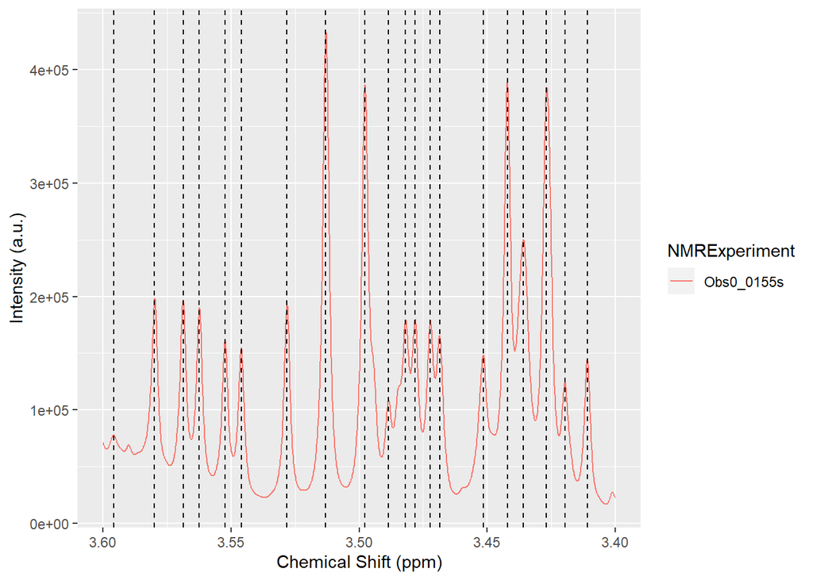

```r
nmr_dataset <- nmr_align(nmr_dataset, peak_data,
                         NMRExp_ref = NMRExp_ref,
                         maxShift_ppm = maxShift_ppm,
                         acceptLostPeak = acceptLostPeak)

plan(sequential)

# Plotting results
nmr_detect_peaks_plot(
  nmr_dataset,
  peak_data,
  NMRExperiment = NMRExp_ref,
  chemshift_range = c(3.40, 3.60)
  )
```

we can take a look into the detected peaks. The interactive plot allows you to zoom in in HTML files.

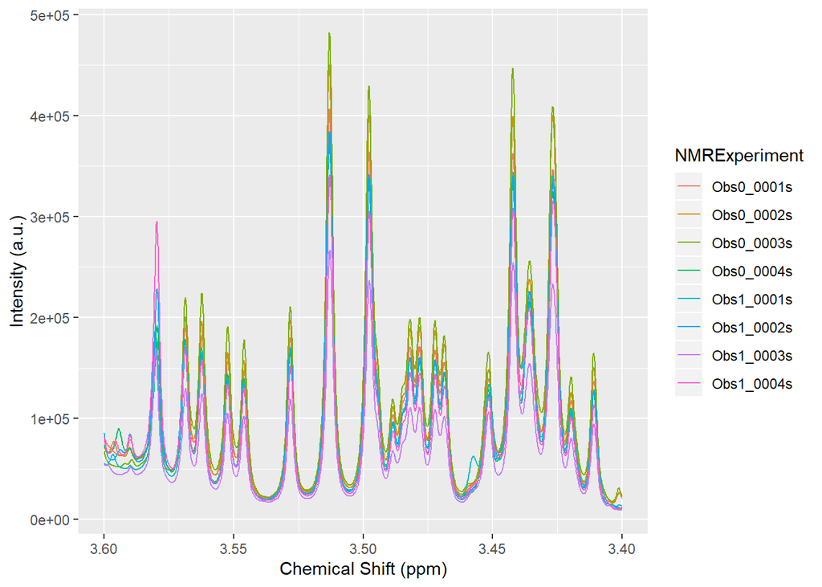

```r
plot(nmr_dataset,
  NMRExperiment = c(
  "Obs0_0001s",
  "Obs0_0002s",
  "Obs0_0003s",
  "Obs0_0004s",
  "Obs1_0001s",
  "Obs1_0002s",
  "Obs1_0003s",
  "Obs1_0004s"),
  chemshift_range = c(3.40, 3.60))
```

# Node 8: Normalization

We can normalize the dataset. This is recommended for biosamples, controlling for dilution factors, irregular pipetting, etc. Probabilistic quotient normalization is one of the most used model-based techniques NMR-based metabolomics.

## Input parameters

```r
# nothing
```

## Code to run

```r
nmr_dataset <- nmr_normalize(nmr_dataset, method = "pqn")
norm_pqn_diagnostic <- nmr_diagnose(nmr_dataset)
gplt_norm_factor_pqn <- norm_pqn_diagnostic$plot
```

# Node 9: Integration

For peak integration, calculation of peak width may be performed automatically (set peak_width_ppm = NULL), from the detected peaks in the reference spectrum (if you wish, you can combine detected peaks other than the reference spectrum, see help), or manually, in which users can select a specific peak width for integrating the detected peaks. This differs than the bucketing approach in which spectra are equally divided into buckets (for example of 0.01 ppm) and this normally leads to a higher number of total variables. this has the inconvenient that several peaks might be split into several parts, lowering the statistical power, and vice-versa, certain overlapping tails might result in false positives because of this noisy parts. However, a good match between them is expected.

## Input parameters

```r
peak_width_ppm <- NULL
```

## Code to run

```r
# be carefull, you integrate based on peaks from a unique ref sample
peak_data_integ <- dplyr::filter(peak_data, NMRExperiment == !!NMRExp_ref)

nmr_peak_table <- nmr_integrate_peak_positions(
  samples = nmr_dataset,
  peak_pos_ppm = peak_data_integ$ppm,
  peak_width_ppm = peak_width_ppm)
```

```
## calculated width for integration is 0.00427905515639537 ppm
```

```r
nmr_peak_table_completed <- get_integration_with_metadata(nmr_peak_table)
```

# Node 10: Machine learning

## Modeling through the multivariate modelling with minimally biased variable selection (MUVR) algorithm

```r
model <- rdCV_PLS_RF(nmr_data(nmr_peak_table),
                     Y = nmr_peak_table_completed$Timepoint)
```

```
##
## Missing ID -> Assume all unique (i.e. sample independence)
## Y is factor -> Classification (2 classes)
```

```
##
##  Elapsed time 0.07416667 mins
```

```r
message("AUC model is ", model$auc[[2]])
```

```
## AUC model is 0.951656490841758
```

## Model performance

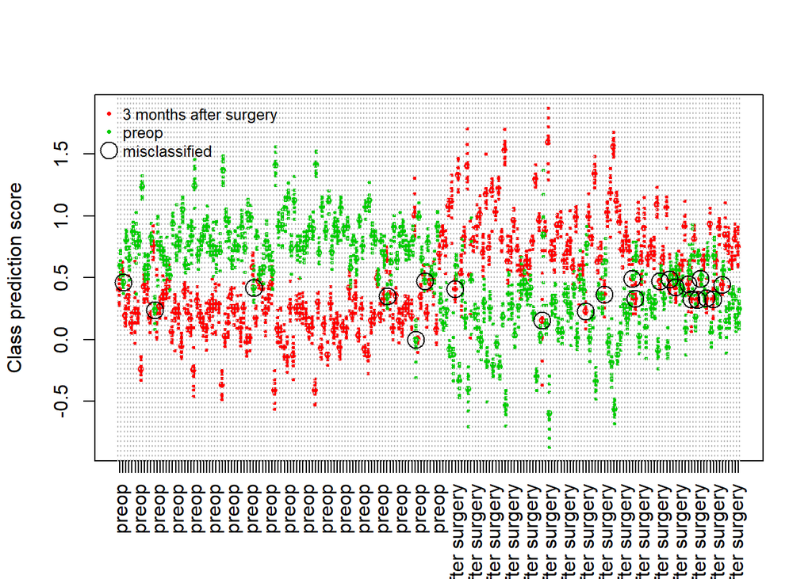

```r
MUVR_model_plot(model)
```

## Permutation test

The function permutation_test_model performs the permutation test. Set the number of permutation at “nPerm”.

```r
permutations = permutation_test_model(model, nPerm = 20)
```

[output not shown]

[output cut: 104 more lines]

[output not shown]

## Permutation test plot

Permutation test plot for multilevel PLS-DA model gives a p-value for the model performance. The actual misclassification departs from the null hypothesis distribution.

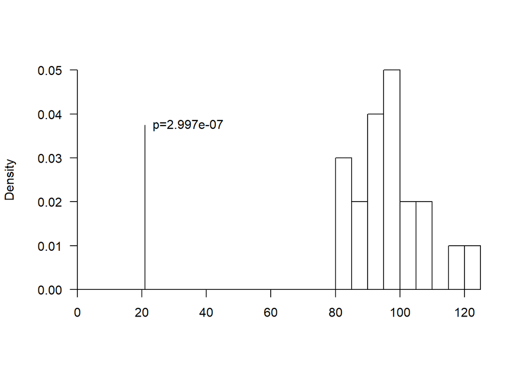

```r
permutation_test_plot(model, permutations)
```

## Autoselected features

Then, we can extract VIP values from the autoselected features.

```r
VIPs= model_VIP(model)
VIPs
```

```
##            order       name    rank
## ppm_3.5798     1 ppm_3.5798   1.440
## ppm_1.2120     2 ppm_1.2120   4.400
## ppm_1.0136     3 ppm_1.0136   5.655
## ppm_1.3515     4 ppm_1.3515   5.960
## ppm_1.0639     5 ppm_1.0639   6.095
## ppm_4.1352     6 ppm_4.1352   9.130
## ppm_1.0521     7 ppm_1.0521   9.855
## ppm_2.2463     8 ppm_2.2463  10.325
## ppm_4.1235     9 ppm_4.1235  12.340
## ppm_1.0018    10 ppm_1.0018  14.115
## ppm_4.1119    11 ppm_4.1119  15.020
## ppm_1.2217    12 ppm_1.2217  17.265
## ppm_1.3399    13 ppm_1.3399  18.300
## ppm_1.1835    14 ppm_1.1835  19.200
## ppm_1.1938    15 ppm_1.1938  20.340
## ppm_3.0602    16 ppm_3.0602  23.715
## ppm_4.1468    17 ppm_4.1468  24.115
## ppm_1.2002    18 ppm_1.2002  24.290
## ppm_0.8461    19 ppm_0.8461  25.765
## ppm_3.6628    20 ppm_3.6628  29.435
## ppm_0.9881    21 ppm_0.9881  30.860
## ppm_0.9775    22 ppm_0.9775  33.240
## ppm_1.2926    23 ppm_1.2926  33.340
## ppm_2.1518    24 ppm_2.1518  33.870
## ppm_3.2311    25 ppm_3.2311  36.645
## ppm_5.2826    26 ppm_5.2826  36.820
## ppm_2.2501    27 ppm_2.2501  37.045
## ppm_0.9670    28 ppm_0.9670  39.365
## ppm_1.5908    29 ppm_1.5908  45.245
## ppm_2.0632    30 ppm_2.0632  46.850
## ppm_1.5995    31 ppm_1.5995  49.475
## ppm_3.8940    32 ppm_3.8940  50.060
## ppm_1.3199    33 ppm_1.3199  50.735
## ppm_2.2324    34 ppm_2.2324  51.835
## ppm_1.2653    35 ppm_1.2653  53.825
## ppm_5.3228    36 ppm_5.3228  53.920
## ppm_0.9422    37 ppm_0.9422  55.990
## ppm_1.5792    38 ppm_1.5792  57.050
## ppm_2.0569    39 ppm_2.0569  57.640
```

[output cut: 15 more lines]

```
## ppm_3.9276    55 ppm_3.9276  87.510
## ppm_3.4109    56 ppm_3.4109  87.925
## ppm_2.7630    57 ppm_2.7630  88.130
## ppm_0.8621    58 ppm_0.8621  89.095
## ppm_1.9937    59 ppm_1.9937  89.135
## ppm_2.0172    60 ppm_2.0172  90.810
## ppm_2.0858    61 ppm_2.0858  91.795
## ppm_2.0045    62 ppm_2.0045  92.610
## ppm_3.4977    63 ppm_3.4977  93.330
## ppm_3.2520    64 ppm_3.2520  96.720
## ppm_3.4268    65 ppm_3.4268  97.255
## ppm_1.2436    66 ppm_1.2436  97.455
## ppm_3.9072    67 ppm_3.9072  97.485
## ppm_0.9071    68 ppm_0.9071  97.730
## ppm_0.9107    69 ppm_0.9107 101.145
```

# Node 11: Identification

Finally, AlpsNMR allows an identification step, in which we can select between plasma/serum, urine and cell functions giving a ranked dataframe with ppm and proposed candidates by the Human Metabolome Database (http://www.hmdb.ca). However, this needs to be double-checked, as there is overlap between several potential compounds for a given ppm value and different specific metabolite-shifts, this should be carefully taken as a first step in the identification. First, we extract a vector with significant ppm values. Then, we run “nmr_identify_regions_blood”. You can set the number of proposed candidates, but in this particular case, we set to 3. Even though, several NAs in the identification corresponded to Supplemental Table 1 in Supplemental Material.

## Autoselected features (blood samples)

```r
ppm_to_assign <- VIPs %>%
  tidyr::separate(col = name,
                  into = c("x1", "ppms"),
                  sep = "_")

ppm_to_assign <- as.numeric(ppm_to_assign$ppms)
assignation <-
  dplyr::select(nmr_identify_regions_blood(ppm_to_assign,
                                           num_proposed_compounds = 3),
                -Height,
                -n_reported_in_Blood,
                -J_Hz)
```

```
## [1] 3.5798
```

```
## your peak at 3.5798 probably corresponds to D-Mannose, Glycerol or L-Threonine
```

```
## [1] 1.212
```

```
## your peak at 1.212 probably corresponds to 3-Hydroxybutyric acid, Isobutyric acid or NA
```

```
## [1] 1.0136
```

```
## your peak at 1.0136 probably corresponds to L-Isoleucine, NA or NA
```

```
## [1] 1.3515
```

```
## your peak at 1.3515 probably corresponds to NA, NA or NA
```

```
## [1] 1.0639
```

```
## your peak at 1.0639 probably corresponds to NA, NA or NA
```

```
## [1] 4.1352
```

```
## your peak at 4.1352 probably corresponds to L-Proline, Uridine or NA
```

```
## [1] 1.0521
```

```
## your peak at 1.0521 probably corresponds to L-Valine, NA or NA
```

```
## [1] 2.2463
```

```
## your peak at 2.2463 probably corresponds to Acetone, NA or NA
```

```
## [1] 4.1235
```

```
## your peak at 4.1235 probably corresponds to L-Lactic acid, L-Proline or Uridine
```

```
## [1] 1.0018
```

```
## your peak at 1.0018 probably corresponds to L-Alpha-aminobutyric acid, L-Isoleucine or L-Valine
```

```
## [1] 4.1119
```

```
## your peak at 4.1119 probably corresponds to L-Lactic acid, NA or NA
```

```
## [1] 1.2217
```

```
## your peak at 1.2217 probably corresponds to 3-Hydroxybutyric acid, Isobutyric acid or NA
```

```
## [1] 1.3399
```

```
## your peak at 1.3399 probably corresponds to L-Lactic acid, L-Threonine or NA
```

```
## [1] 1.1835
```

```
## your peak at 1.1835 probably corresponds to Ethanol, Isopropyl alcohol or NA
```

```
## [1] 1.1938
```

```
## your peak at 1.1938 probably corresponds to Ethanol, NA or NA
```

```
## [1] 3.0602
```

```
## your peak at 3.0602 probably corresponds to Ornithine, NA or NA
```

```
## [1] 4.1468
```

```
## your peak at 4.1468 probably corresponds to L-Proline, Uridine or NA
```

```
## [1] 1.2002
```

```
## your peak at 1.2002 probably corresponds to NA, NA or NA
```

```
## [1] 0.8461
```

```
## your peak at 0.8461 probably corresponds to 2-Hydroxy-3-methylbutyric acid, NA or NA
```

```
## [1] 3.6628
```

```
## your peak at 3.6628 probably corresponds to D-Mannose, Ethanol or Glycerol
```

```
## [1] 0.9881
```

```
## your peak at 0.9881 probably corresponds to L-Alpha-aminobutyric acid, L-Valine or NA
```

```
## [1] 0.9775
```

```
## your peak at 0.9775 probably corresponds to 2-Hydroxy-3-methylbutyric acid, L-Leucine or L-Valine
```

```
## [1] 1.2926
```

```
## your peak at 1.2926 probably corresponds to NA, NA or NA
```

```
## [1] 2.1518
```

```
## your peak at 2.1518 probably corresponds to L-Acetylcarnitine, L-Glutamine or NA
```

```
## [1] 3.2311
```

```
## your peak at 3.2311 probably corresponds to L-Arginine, L-Histidine or NA
```

```
## [1] 5.2826
```

```
## your peak at 5.2826 probably corresponds to NA, NA or NA
```

```
## [1] 2.2501
```

```
## your peak at 2.2501 probably corresponds to NA, NA or NA
```

```
## [1] 0.967
```

```
## your peak at 0.967 probably corresponds to 2-Hydroxy-3-methylbutyric acid, L-Leucine or NA
```

```
## [1] 1.5908
```

```
## your peak at 1.5908 probably corresponds to NA, NA or NA
```

```
## [1] 2.0632
```

```
## your peak at 2.0632 probably corresponds to Acetylglycine, Isovaleric acid or L-Glutamic acid
```

```
## [1] 1.5995
```

```
## your peak at 1.5995 probably corresponds to NA, NA or NA
```

```
## [1] 3.894
```

```
## your peak at 3.894 probably corresponds to Betaine, D-Glucose or D-Mannose
```

```
## [1] 1.3199
```

```
## your peak at 1.3199 probably corresponds to L-Threonine, NA or NA
```

```
## [1] 2.2324
```

```
## your peak at 2.2324 probably corresponds to Acetone, NA or NA
```

```
## [1] 1.2653
```

```
## your peak at 1.2653 probably corresponds to 3-Hydroxyisovaleric acid, L-Isoleucine or NA
```

```
## [1] 5.3228
```

```
## your peak at 5.3228 probably corresponds to NA, NA or NA
```

```
## [1] 0.9422
```

```
## your peak at 0.9422 probably corresponds to Ketoleucine, L-Isoleucine or NA
```

```
## [1] 1.5792
```

```
## your peak at 1.5792 probably corresponds to NA, NA or NA
```

```
## [1] 2.0569
```

```
## your peak at 2.0569 probably corresponds to Acetylglycine, Isovaleric acid or L-Glutamic acid
```

```
## [1] 2.2353
```

```
## your peak at 2.2353 probably corresponds to Acetone, NA or NA
```

```
## [1] 2.2611
```

```
## your peak at 2.2611 probably corresponds to L-Valine, NA or NA
```

```
## [1] 1.5039
```

```
## your peak at 1.5039 probably corresponds to NA, NA or NA
```

```
## [1] 3.3799
```

```
## your peak at 3.3799 probably corresponds to D-Mannose, NA or NA
```

```
## [1] 0.9546
```

```
## your peak at 0.9546 probably corresponds to 2-Hydroxy-3-methylbutyric acid, Ketoleucine or L-Isoleucine
```

```
## [1] 2.097
```

```
## your peak at 2.097 probably corresponds to Ketoleucine, NA or NA
```

```
## [1] 3.4782
```

```
## your peak at 3.4782 probably corresponds to D-Glucose, Sucrose or NA
```

```
## [1] 2.235
```

```
## your peak at 2.235 probably corresponds to Acetone, NA or NA
```

```
## [1] 3.8118
```

```
## your peak at 3.8118 probably corresponds to D-Mannose, Uridine or NA
```

```
## [1] 3.2807
```

```
## your peak at 3.2807 probably corresponds to Myoinositol, NA or NA
```

```
## [1] 3.6894
```

```
## your peak at 3.6894 probably corresponds to 1-Methylhistidine, L-Isoleucine or Sucrose
```

```
## [1] 3.4722
```

```
## your peak at 3.4722 probably corresponds to D-Glucose, Sucrose or NA
```

```
## [1] 1.4916
```

```
## your peak at 1.4916 probably corresponds to L-Alanine, NA or NA
```

```
## [1] 0.8955
```

```
## your peak at 0.8955 probably corresponds to NA, NA or NA
```

```
## [1] 3.2673
```

```
## your peak at 3.2673 probably corresponds to 3-Methylhistidine, Betaine or NA
```

```
## [1] 3.9276
```

```
## your peak at 3.9276 probably corresponds to Creatine, D-Mannose or Uridine
```

```
## [1] 3.4109
```

```
## your peak at 3.4109 probably corresponds to D-Glucose, L-Carnitine or L-Proline
```

```
## [1] 2.763
```

```
## your peak at 2.763 probably corresponds to NA, NA or NA
```

```
## [1] 0.8621
```

```
## your peak at 0.8621 probably corresponds to NA, NA or NA
```

```
## [1] 1.9937
```

```
## your peak at 1.9937 probably corresponds to L-Isoleucine, L-Proline or NA
```

```
## [1] 2.0172
```

```
## your peak at 2.0172 probably corresponds to 2-Hydroxy-3-methylbutyric acid, L-Proline or NA
```

```
## [1] 2.0858
```

```
## your peak at 2.0858 probably corresponds to L-Proline, NA or NA
```

```
## [1] 2.0045
```

```
## your peak at 2.0045 probably corresponds to L-Proline, NA or NA
```

```
## [1] 3.4977
```

```
## your peak at 3.4977 probably corresponds to NA, NA or NA
```

```
## [1] 3.252
```

```
## your peak at 3.252 probably corresponds to 3-Methylhistidine, Betaine or D-Glucose
```

```
## [1] 3.4268
```

```
## your peak at 3.4268 probably corresponds to D-Glucose, L-Carnitine or L-Proline
```

```
## [1] 1.2436
```

```
## your peak at 1.2436 probably corresponds to NA, NA or NA
```

```
## [1] 3.9072
```

```
## your peak at 3.9072 probably corresponds to Betaine, D-Glucose or D-Mannose
```

```
## [1] 0.9071
```

```
## your peak at 0.9071 probably corresponds to 3-Methyl-2-oxovaleric acid, Isovaleric acid or NA
```

```
## [1] 0.9107
```

```
## your peak at 0.9107 probably corresponds to 3-Methyl-2-oxovaleric acid, Isovaleric acid or NA
```

```r
assignation_NArm <- na.omit(assignation)
assignation
```

```
##                            Metabolite   HMDB_code Shift_ppm Type
## 7      2-Hydroxy-3-methylbutyric acid   HMDB00407     0.835    d
## NA15                             <NA>        <NA>        NA <NA>
## NA.19                            <NA>        <NA>        NA <NA>
## NA45                             <NA>        <NA>        NA <NA>
## NA.129                           <NA>        <NA>        NA <NA>
## NA.213                           <NA>        <NA>        NA <NA>
## NA42                             <NA>        <NA>        NA <NA>
## NA.127                           <NA>        <NA>        NA <NA>
## NA.211                           <NA>        <NA>        NA <NA>
## 17         3-Methyl-2-oxovaleric acid   HMDB00491     0.915    t
## 88                    Isovaleric acid   HMDB00718     0.915    d
## NA52                             <NA>        <NA>        NA <NA>
## 171        3-Methyl-2-oxovaleric acid   HMDB00491     0.915    t
## 881                   Isovaleric acid   HMDB00718     0.915    d
## NA53                             <NA>        <NA>        NA <NA>
## 135                      L-Isoleucine   HMDB00172     0.941    t
## 92                        Ketoleucine   HMDB00695     0.945    d
## NA29                             <NA>        <NA>        NA <NA>
## 1351                     L-Isoleucine   HMDB00172     0.941    t
## 921                       Ketoleucine   HMDB00695     0.945    d
## 102    2-Hydroxy-3-methylbutyric acid   HMDB00407     0.965    d
## 1421                        L-Leucine   HMDB00687     0.963    t
## 101    2-Hydroxy-3-methylbutyric acid   HMDB00407     0.965    d
## NA22                             <NA>        <NA>        NA <NA>
## 1782                         L-Valine   HMDB00883     0.991    d
## 142                         L-Leucine   HMDB00687     0.963    t
## 10     2-Hydroxy-3-methylbutyric acid   HMDB00407     0.965    d
## 1781                         L-Valine   HMDB00883     0.991    d
## 1031        L-Alpha-aminobutyric acid   HMDB00452     0.997    t
## NA16                             <NA>        <NA>        NA <NA>
## 178                          L-Valine   HMDB00883     0.991    d
## 1371                     L-Isoleucine   HMDB00172     1.012    d
## 103         L-Alpha-aminobutyric acid   HMDB00452     0.997    t
## 137                      L-Isoleucine   HMDB00172     1.012    d
## NA1                              <NA>        <NA>        NA <NA>
## NA.1                             <NA>        <NA>        NA <NA>
## 179                          L-Valine   HMDB00883     1.044    d
## NA5                              <NA>        <NA>        NA <NA>
## NA.13                            <NA>        <NA>        NA <NA>
```

[output cut: 361 more lines]

```
## 140             2235.17500        4.1235
## 1621             151.34545        4.1235
## 2221               3.11000        4.1235
## 162              151.34545        4.1352
## 222                3.11000        4.1352
## NA4                     NA        4.1352
## 1622             151.34545        4.1468
## 2222               3.11000        4.1468
## NA13                    NA        4.1468
## NA20                    NA        5.2826
## NA.111                  NA        5.2826
## NA.24                   NA        5.2826
## NA28                    NA        5.3228
## NA.117                  NA        5.3228
## NA.28                   NA        5.3228
```

```r
assignation_NArm
```

```
##                          Metabolite   HMDB_code Shift_ppm Type
## 7    2-Hydroxy-3-methylbutyric acid   HMDB00407     0.835    d
## 17       3-Methyl-2-oxovaleric acid   HMDB00491     0.915    t
## 88                  Isovaleric acid   HMDB00718     0.915    d
## 171      3-Methyl-2-oxovaleric acid   HMDB00491     0.915    t
## 881                 Isovaleric acid   HMDB00718     0.915    d
## 135                    L-Isoleucine   HMDB00172     0.941    t
## 92                      Ketoleucine   HMDB00695     0.945    d
## 1351                   L-Isoleucine   HMDB00172     0.941    t
## 921                     Ketoleucine   HMDB00695     0.945    d
## 102  2-Hydroxy-3-methylbutyric acid   HMDB00407     0.965    d
## 1421                      L-Leucine   HMDB00687     0.963    t
## 101  2-Hydroxy-3-methylbutyric acid   HMDB00407     0.965    d
## 1782                       L-Valine   HMDB00883     0.991    d
## 142                       L-Leucine   HMDB00687     0.963    t
```

[output cut: 193 more lines]